# Part 3: 2nd_test

WangPeng, Qu Mengyuan

2019/10/27

# 1 Output of 2nd test on one-year data

```r
df <- left_join(close,vol,by = c("Date"="observation_date"))
df <- mutate(df, month = as.numeric(substring(df$Date,6,7)))
max_drawdown <- rep(0,12)
sharpe_ratio <- rep(0,12)
final_Pnl <- rep(0,12)
implied_strike <- rep(0,12)
S0 <- rep(0,12)
maturity_date <- c()
# If you want to use type with a data frame.
type <- c("c","c","p","c","c","p","c","c","c","p","p","p")
df1 <- dplyr::filter(df, month == 0)
realized_vol <- rep(0,12)
implied_vol <-rep(0,12)

cal <- function(Type, Sp, maturity, sig){
  Str <- Sp
  for(jj in round(Sp-100):round(Sp+100)){
    if( (GBSGreeks("delta", TypeFlag = Type, S=Sp, X = jj ,
                 Time = maturity, r = 0.8/100, b = 0, sigma = sig ) >= 0.245)&(
                   GBSGreeks("delta", TypeFlag = Type, S=Sp, X = jj ,
                             Time = maturity, r = 0.8/100, b = 0, sigma = sig ) <= 0.255))
                   {
      Str <- jj
    }
  }
  return(Str)
}

for(ii in 1:12){
  df_sub <- dplyr::filter(df, month == ii)
  start_date <- min(df_sub$Date)
  end_date <- max(df_sub$Date)
  maturity_date <- c(maturity_date, as.Date(end_date))
  start_price <- df_sub$Close[1]
  S0[ii] <- start_price
  df_sub <- mutate(df_sub,volatility = VXAZNCLS/100)
  start_volatility <- df_sub$volatility[1]
  implied_vol[ii] <- start_volatility
  df_sub <- mutate(df_sub,time_to_M = as.numeric(difftime(as.POSIXct(end_date), as.POSIXct(df_sub$Date, tz="UTC"),
                                                          units="days")/365))

  implied_strike[ii] <- cal(type[ii],start_price,df_sub$time_to_M[1],start_volatility)

  df_sub <- df_sub %>%
    mutate(premium = 100 * GBSOption(TypeFlag = type[ii],
                                                     S = Close,
                                                     X = implied_strike[ii], # missing
                                                     Time = time_to_M,
                                                     r = 0.8/100, # interest rate
                                                     b = 0,
                                                     sigma = start_volatility)@price)%>%
    mutate(Option_DoD_PnL = ifelse(Date == start_date,
                                   # On the 1st date, we count the cost of buying the option
                                   # premium * (-1),
                                   0,
                                   premium - dplyr::lag(premium)))

  df_sub <- df_sub %>%
    rowwise() %>%
    mutate(delta_hedge = 100 * GBSGreeks("delta", TypeFlag = type[ii], S=Close, X = implied_strike[ii], Time = time_to_M,
                                         r = 0.8/100, b = 0, sigma = start_volatility )  * (-1)) %>%
    ungroup()%>%
    mutate(Hedging_DoD_Pnl = ifelse(Date == start_date,
                                    0,
                                    dplyr::lag(delta_hedge) * (Close - dplyr::lag(Close))))

  df_sub <- df_sub%>%
    mutate(daily_PnL = Option_DoD_PnL + Hedging_DoD_Pnl,
           Option_Final_PnL = cumsum(Option_DoD_PnL),
           Hedging_Final_PnL = cumsum(Hedging_DoD_Pnl),

           Final_PnL = Option_Final_PnL + Hedging_Final_PnL,
           max_d = cummax(Final_PnL) - cummin(Final_PnL),
           portfolio_value = Close * delta_hedge + premium,
           return = ifelse(Date == start_date,
                           0,
                           daily_PnL/dplyr::lag(portfolio_value)))

    ln_price <- log(df_sub$Close)/sqrt(1/252)

   realized_vol[ii] <- sdDiff(ln_price)

  df1 <- bind_rows(df1,df_sub)

  final_Pnl[ii] <- df_sub$Final_PnL[nrow(df_sub)]
  max_drawdown[ii] <-
    {
      xs <- df_sub$Final_PnL
      max(cummax(xs) - cummin(xs))
    }

  sharpe_ratio[ii] <- (mean(df_sub$return[2:length(df_sub$return)])-0.008/250)/stdev(df_sub$return[2:length(df_sub$return)])
  }
backtest <- tibble(Option_Expiry_Date = c(1:12), Sharpe_ratio = sharpe_ratio,
                   Final_PnL = final_Pnl, Max_Drawdown = max_drawdown,
                   Implied_strike = implied_strike, S0 = S0,
                   Realized_vol = realized_vol, Implied_vol = implied_vol)
backtest
```

```
## # A tibble: 12 x 8
##    Option_Expiry_D~ Sharpe_ratio Final_PnL Max_Drawdown Implied_strike
##               <int>        <dbl>     <dbl>        <dbl>          <dbl>
##  1                1       0.305      -451.         650.          1255
##  2                2       0.0165     -311.        1053.          1390
##  3                3       0.234      2277.        3706.          1493.
##  4                4       0.331     -1179.        1497.          1372.
##  5                5       0.972     -1902.        1902.          1673
##  6                6       0.172       465.        1068.          1642.
##  7                7       0.724     -1776.        1776.          1714.
##  8                8       0.477     -1821.        2733.          1897
##  9                9       0.354       103.         216.          2140
## 10               10       0.140       870.        1235.          2004.
## 11               11       0.113      2118.        3390.          1666.
## 12               12       0.284      1802.        1802.          1772.
## # ... with 3 more variables: S0 <dbl>, Realized_vol <dbl>,
## #   Implied_vol <dbl>
```

# 2 Analysis

## 2.1 Final Pnl

### 2.1.1 One trade

Using an option of 25% delta, the final profit and loss on Option side are positive at a high level almost all the time while that on Hedge side change violently and are always negative.

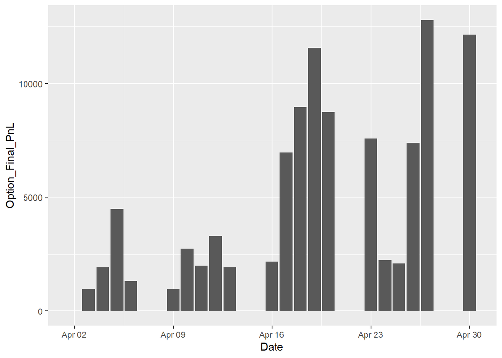

```r
res1 <-dplyr::filter(df1, month == 4)
ggplot(res1,aes(Date,Option_Final_PnL))+geom_col()
```

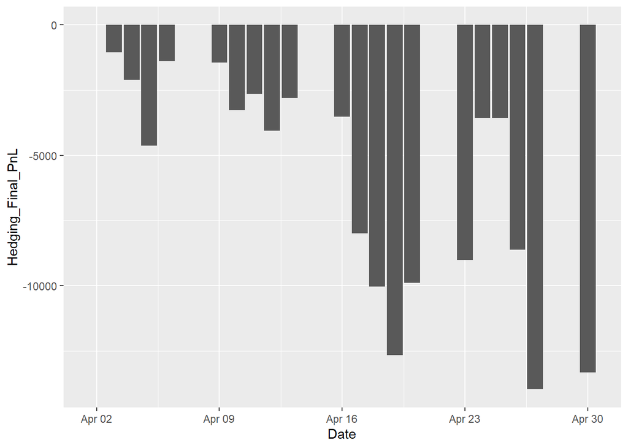

```r
ggplot(res1,aes(Date,Hedging_Final_PnL))+geom_col()
```

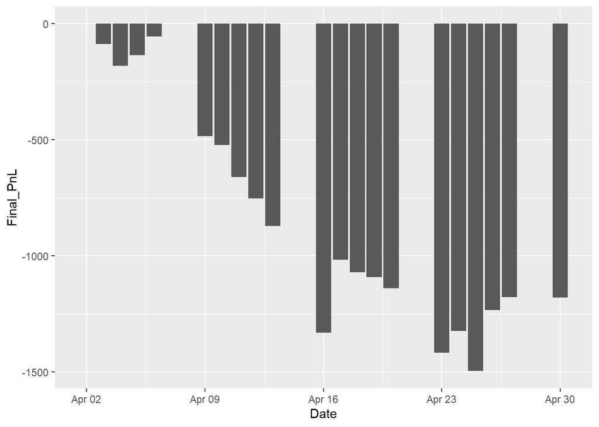

```r
ggplot(res1,aes(Date,Final_PnL))+geom_col()
```

### 2.1.2 Distribution

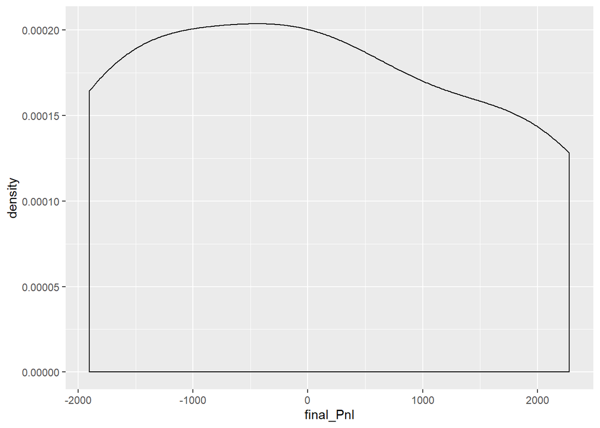

```r
ggplot(backtest,aes(final_Pnl))+geom_density()
```

## 2.2 Max Drawdown

### 2.2.1 One Trade

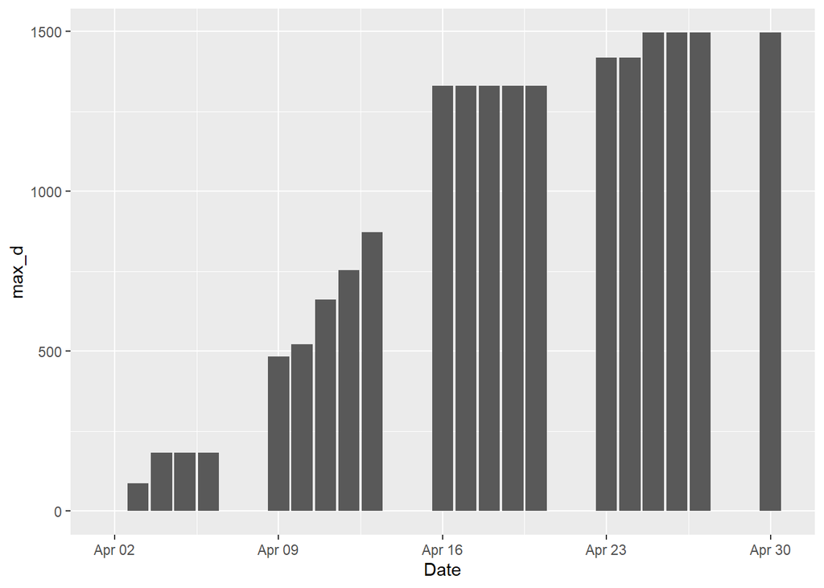

```r
res2 <-dplyr::filter(df1, month == 4)
ggplot(res2,aes(Date,max_d))+geom_col()
```

### 2.2.2 Distribution

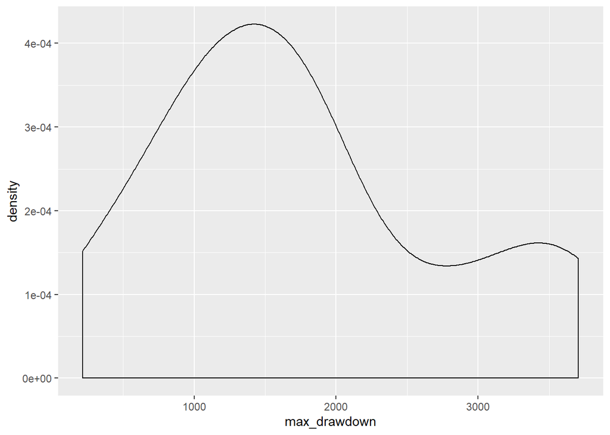

```r
ggplot(backtest,aes(max_drawdown))+geom_density()
```

## 2.3 Final Pnl vs Time to maturity

As time to maturity extends, final profit on **Option** side *decreases* while that on **Hedge** side *increases*.

As whole, final loss of delta hedge strategy increases stably as time to maturity reduces and converges to a certain number.

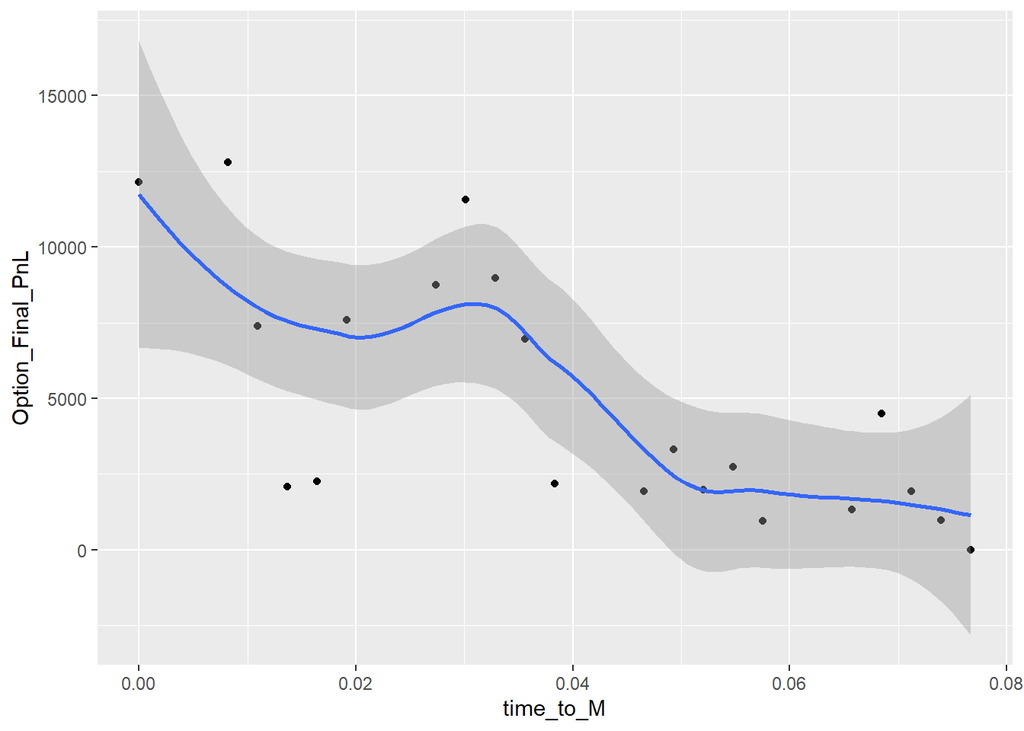

```r
res3 <-dplyr::filter(df1, month == 4)
ggplot(res3, aes(time_to_M,Option_Final_PnL ))+geom_point()+geom_smooth()
```

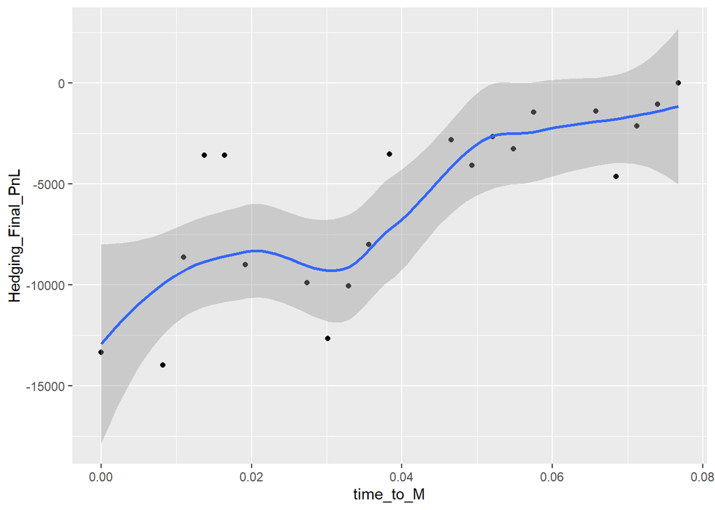

```r
ggplot(res3, aes(time_to_M,Hedging_Final_PnL ))+geom_point()+geom_smooth()
```

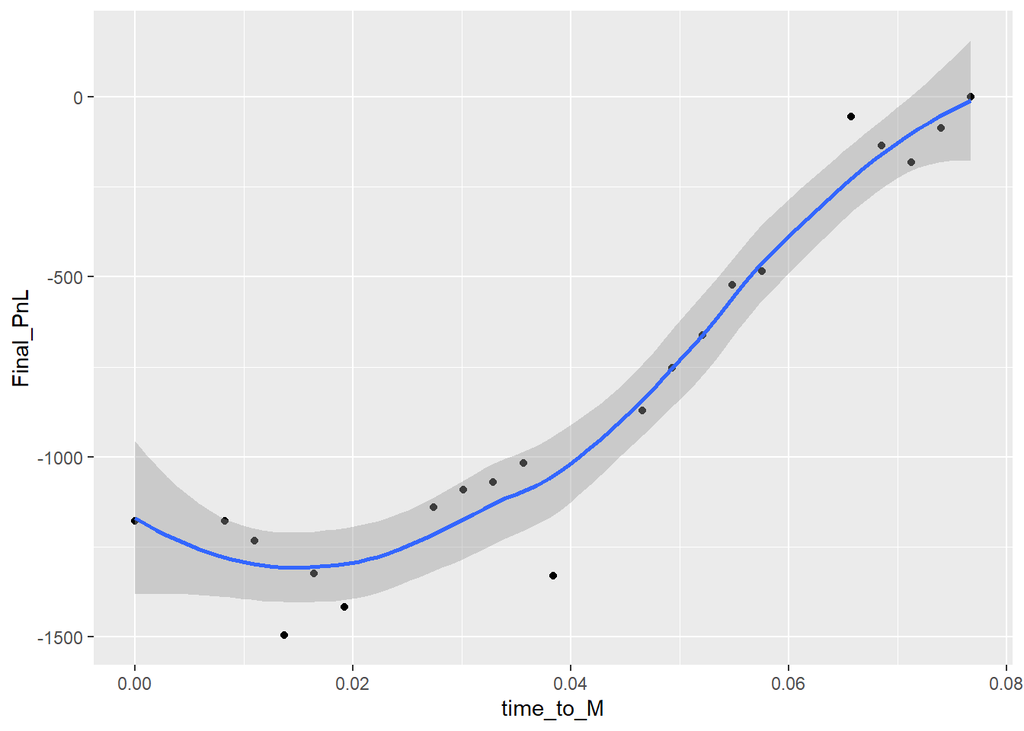

```r
ggplot(res3, aes(time_to_M,Final_PnL ))+geom_point()+geom_smooth()
```

## 2.4 Daily Pnl vs Stock Price

Generally, Daily Profit on Option side oscillates mildly with Stock Close Price changing while there is no obvious relationship between stock close price and Daily Profit and loss on Hedge side.

As a whole, however, daily profit and loss of delta hedge strategy keeps almost the **same**, which means the strategy can control loss in a reasonable range effectively.

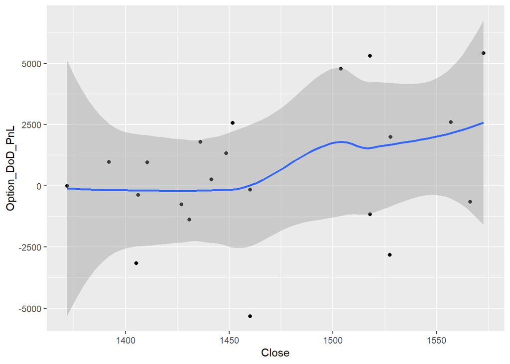

```r
res4 <-dplyr::filter(df1, month == 4)
ggplot(res4, aes(Close,Option_DoD_PnL))+geom_point()+geom_smooth()
```

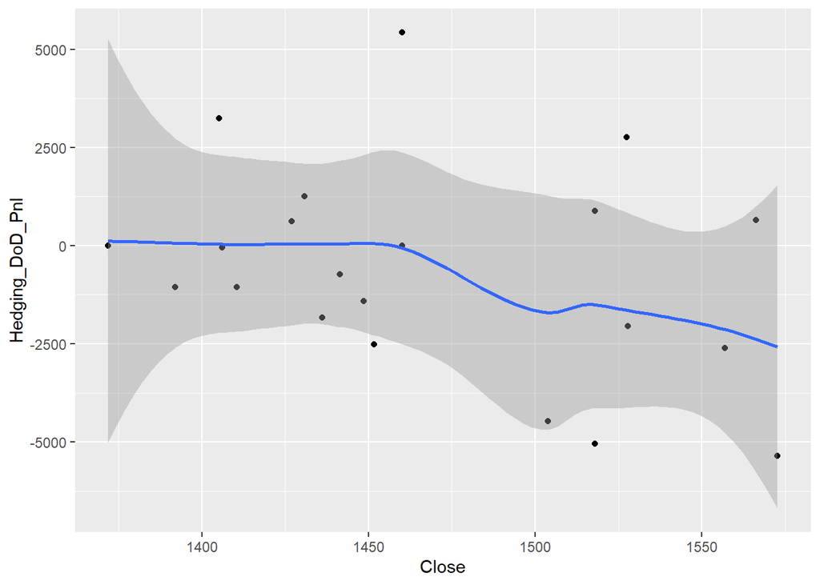

```r
ggplot(res4, aes(Close,Hedging_DoD_Pnl))+geom_point()+geom_smooth()
```

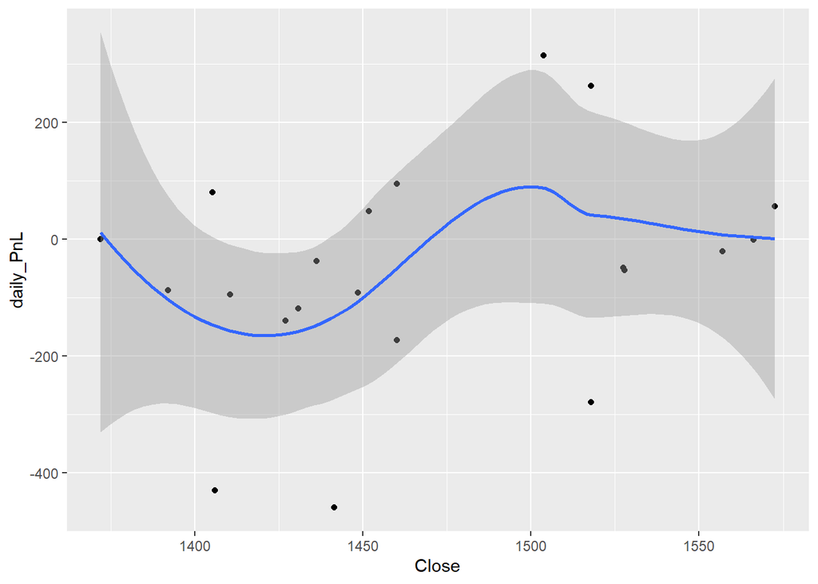

```r
ggplot(res4, aes(Close,daily_PnL))+geom_point()+geom_smooth()
```

## 2.5 Sharpe ratio vs Maturity date

There is no direct evidence which indicates a certain relationship between strategy’s Sharpe Ratio and time to maturity.

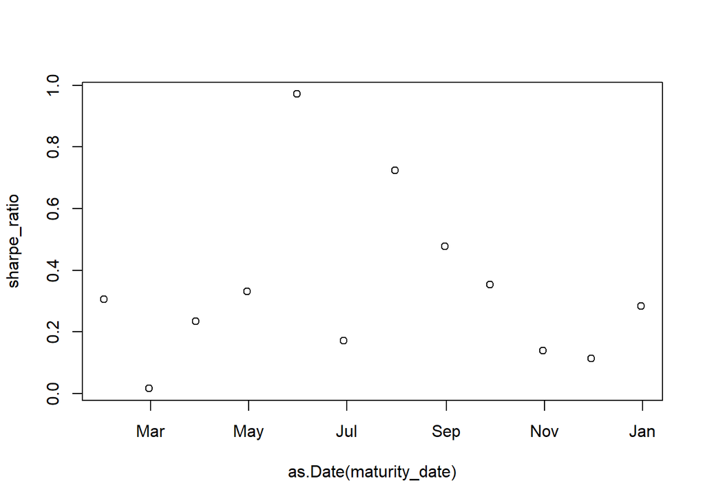

```r
plot(as.Date(maturity_date), sharpe_ratio)
```

## 2.6 Sharpe ratio vs difference between implied volatility and realized volatility

Generally speaking, ignoring outliers, sharpe ratio is a **linear** function of the square of difference between implied volatility and realized volatility.

```r
backtest <- mutate(backtest, diff_vol=(Implied_vol - Realized_vol)**2)
lm.sol <- lm(backtest$Sharpe_ratio~backtest$diff_vol)
summary(lm.sol)
```

```
##
## Call:
## lm(formula = backtest$Sharpe_ratio ~ backtest$diff_vol)
##
## Residuals:
##      Min       1Q   Median       3Q      Max
## -0.35676 -0.09793 -0.02887  0.10009  0.47251
##
## Coefficients:
##                   Estimate Std. Error t value Pr(>|t|)
## (Intercept)         0.1782     0.1134   1.572   0.1471
## backtest$diff_vol   8.9765     4.8181   1.863   0.0921 .
## ---
## Signif. codes:  0 '***' 0.001 '**' 0.01 '*' 0.05 '.' 0.1 ' ' 1
##
## Residual standard error: 0.2445 on 10 degrees of freedom
## Multiple R-squared:  0.2577, Adjusted R-squared:  0.1834
## F-statistic: 3.471 on 1 and 10 DF,  p-value: 0.09205
```

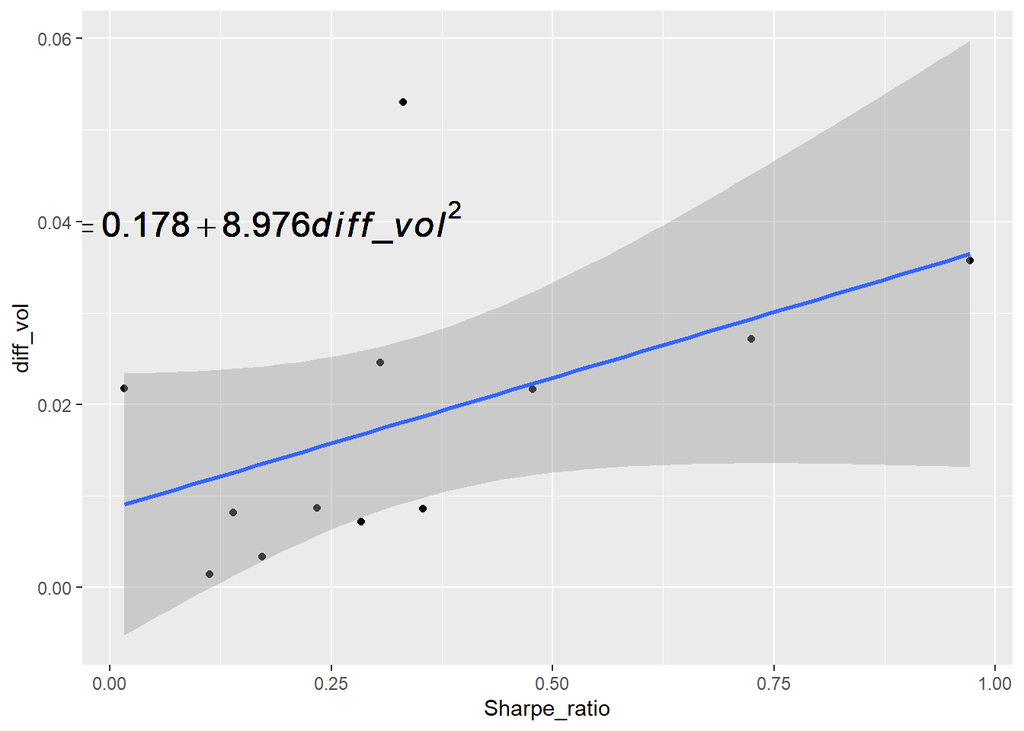

```r
formula <- sprintf("italic(Sharpe)==%.3f+%.3f*italic(diff_vol)^2",
                   round(lm.sol$coefficients[1][1],3),round(lm.sol$coefficients[2],3))
ggplot(backtest,aes(Sharpe_ratio,diff_vol)) +
  geom_point() +
  geom_smooth(method = "lm") +
  geom_text(x=-0.2,aes(label=formula,y=0.04),parse=TRUE,hjust=0,size=6)
```

## 2.7 implied Strike Price vs Stock Price

Implied Strike Price is a **linear** function of Stock Price, **positive** related.

```r
lm.sol <- lm(backtest$Implied_strike~backtest$S0)
summary(lm.sol)
```

```
##
## Call:
## lm(formula = backtest$Implied_strike ~ backtest$S0)
##
## Residuals:
##    Min     1Q Median     3Q    Max
## -40.89 -30.95 -23.77  52.07  65.24
##
## Coefficients:
##              Estimate Std. Error t value Pr(>|t|)
## (Intercept) -20.11534   91.31780   -0.22     0.83
## backtest$S0   1.03044    0.05514   18.69 4.16e-09 ***
## ---
## Signif. codes:  0 '***' 0.001 '**' 0.01 '*' 0.05 '.' 0.1 ' ' 1
##
## Residual standard error: 46.24 on 10 degrees of freedom
## Multiple R-squared:  0.9722, Adjusted R-squared:  0.9694
## F-statistic: 349.3 on 1 and 10 DF,  p-value: 4.16e-09
```

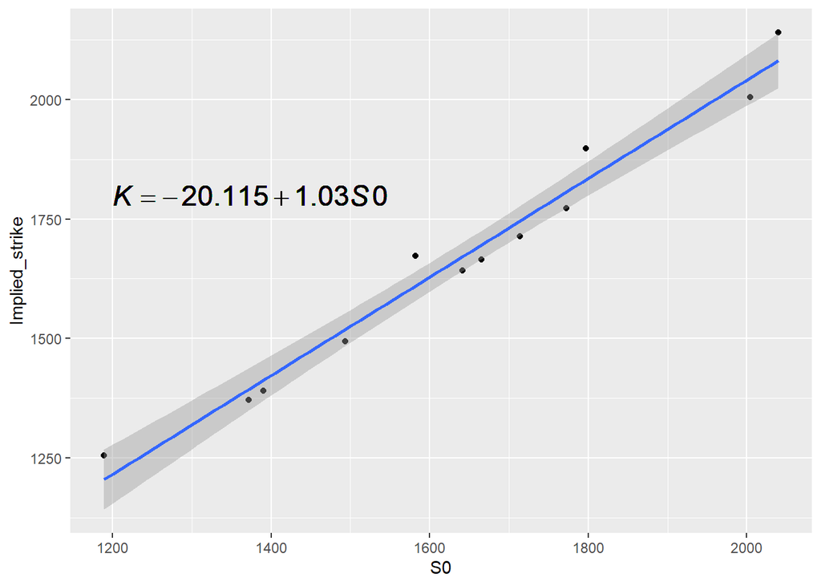

```r
formula <- sprintf("italic(K)==%.3f+%.3f*italic(S0)",
                   round(lm.sol$coefficients[1][1],3),round(lm.sol$coefficients[2],3))
ggplot(backtest,aes(S0,Implied_strike)) +
  geom_point() +
  geom_smooth(method = "lm") +
  geom_text(x=1200,aes(label=formula,y=1800),parse=TRUE,hjust=0,size=6)
```